# Supervised Learning — Regression Algorithms

### Logistic Regression (Credit Card Fraud Detection) & Linear Regression (Insurance Cost Prediction)

**Supervised learning** trains a model on examples whose correct answer (the *label* or *target*) is already known, so it can predict that answer for new, unseen data. The "regression" family covered here shares one idea: learn a **weighted sum of the input features**

$$z = \beta_0 + \beta_1x_1 + \beta_2x_2 + \dots + \beta_nx_n$$

and use it in two different ways:

|  | **Logistic Regression** (Part A) | **Linear Regression** (Part B) |
| --- | --- | --- |
| Target type | Category / class (fraud vs. not fraud) | Continuous number (e.g. insurance cost) |
| Output | $P(y=1) = \sigma(z) = \dfrac{1}{1+e^{-z}}$ | $\hat{y} = z$ |
| Loss minimised | Log-loss (cross-entropy) | Mean squared error (ordinary least squares) |
| Typical metrics | Accuracy, precision, recall, F1, ROC-AUC | R², MAE, RMSE |

Despite its name, logistic regression is a **classification** algorithm: it squeezes the linear score through the sigmoid function to get a probability, then applies a threshold (0.5 by default) to decide the class.

**Workflow followed in both parts**

1. Load the data and inspect its structure
2. Preprocess: missing values, duplicates, encoding, scaling
3. Exploratory data analysis (EDA)
4. Split into **train (70%)** and **test (30%)**
5. Train the model
6. Evaluate on the unseen test set and interpret the results

> **Data files:** download `creditcard.csv` (https://www.kaggle.com/datasets/mlg-ulb/creditcardfraud) and `insurance.csv` / `insurance_2.csv` (https://www.kaggle.com/datasets/mirichoi0218/insurance) and place them in the same folder as this notebook.

```python
import numpy as np
import pandas as pd
import matplotlib.pyplot as plt
import seaborn as sns
from matplotlib.colors import LinearSegmentedColormap

from sklearn.model_selection import train_test_split, cross_val_score
from sklearn.preprocessing import StandardScaler
from sklearn.linear_model import LogisticRegression, LinearRegression
from sklearn.metrics import (accuracy_score, confusion_matrix, classification_report,
                             precision_score, recall_score, f1_score,
                             roc_auc_score, average_precision_score, precision_recall_curve,
                             r2_score, mean_absolute_error, mean_squared_error)

pd.set_option("display.max_columns", 40)
pd.set_option("display.float_format", lambda v: f"{v:,.4f}")

# Consistent, colour-blind-friendly chart styling
BLUE, ORANGE, GRAY = "#2a78d6", "#eb6834", "#8a8984"
SEQ_BLUE = LinearSegmentedColormap.from_list("seq_blue", ["#f4f8fd", "#86b6ef", "#2a78d6", "#0d366b"])
DIVERGING = LinearSegmentedColormap.from_list("div", ["#2a78d6", "#f0efec", "#eb6834"])
plt.rcParams.update({"figure.dpi": 100, "axes.spines.top": False, "axes.spines.right": False,
                     "axes.grid": True, "grid.color": "#e6e5e1", "grid.linewidth": 0.6,
                     "axes.axisbelow": True, "axes.edgecolor": "#8a8984", "font.size": 10})

RANDOM_STATE = 42
print("Libraries loaded.")
```

```
Libraries loaded.
```

# Part A — Credit Card Fraud Detection with Logistic Regression

**Problem statement:** Using the Kaggle *Credit Card Fraud Detection* dataset, build a machine-learning model that detects whether a credit card transaction is fraudulent. Demonstrate data preprocessing and analysis, split the data into train (0.7) and test (0.3), build the model with **logistic regression**, and evaluate its accuracy.

**About the data:** transactions made by European cardholders over two days in September 2013.

- `Time` – seconds elapsed since the first transaction in the dataset
- `V1` … `V28` – anonymised features produced by a PCA transformation (the original features are confidential)
- `Amount` – transaction amount
- `Class` – **target**: 1 = fraud, 0 = genuine

## A.1 Load and inspect the data

```python
cc = pd.read_csv("creditcard.csv")
print("Shape (rows, columns):", cc.shape)
cc.head()
```

```
Shape (rows, columns): (284807, 31)
```

|  | Time | V1 | V2 | V3 | V4 | V5 | V6 | V7 | V8 | V9 | V10 | V11 | V12 | V13 | V14 | V15 | V16 | V17 | V18 | V19 | V20 | V21 | V22 | V23 | V24 | V25 | V26 | V27 | V28 | … |
| --- | --- | --- | --- | --- | --- | --- | --- | --- | --- | --- | --- | --- | --- | --- | --- | --- | --- | --- | --- | --- | --- | --- | --- | --- | --- | --- | --- | --- | --- | --- |
| 0 | 0.0000 | -1.3598 | -0.0728 | 2.5363 | 1.3782 | -0.3383 | 0.4624 | 0.2396 | 0.0987 | 0.3638 | 0.0908 | -0.5516 | -0.6178 | -0.9914 | -0.3112 | 1.4682 | -0.4704 | 0.2080 | 0.0258 | 0.4040 | 0.2514 | -0.0183 | 0.2778 | -0.1105 | 0.0669 | 0.1285 | -0.1891 | 0.1336 | -0.0211 | … |
| 1 | 0.0000 | 1.1919 | 0.2662 | 0.1665 | 0.4482 | 0.0600 | -0.0824 | -0.0788 | 0.0851 | -0.2554 | -0.1670 | 1.6127 | 1.0652 | 0.4891 | -0.1438 | 0.6356 | 0.4639 | -0.1148 | -0.1834 | -0.1458 | -0.0691 | -0.2258 | -0.6387 | 0.1013 | -0.3398 | 0.1672 | 0.1259 | -0.0090 | 0.0147 | … |
| 2 | 1.0000 | -1.3584 | -1.3402 | 1.7732 | 0.3798 | -0.5032 | 1.8005 | 0.7915 | 0.2477 | -1.5147 | 0.2076 | 0.6245 | 0.0661 | 0.7173 | -0.1659 | 2.3459 | -2.8901 | 1.1100 | -0.1214 | -2.2619 | 0.5250 | 0.2480 | 0.7717 | 0.9094 | -0.6893 | -0.3276 | -0.1391 | -0.0554 | -0.0598 | … |
| 3 | 1.0000 | -0.9663 | -0.1852 | 1.7930 | -0.8633 | -0.0103 | 1.2472 | 0.2376 | 0.3774 | -1.3870 | -0.0550 | -0.2265 | 0.1782 | 0.5078 | -0.2879 | -0.6314 | -1.0596 | -0.6841 | 1.9658 | -1.2326 | -0.2080 | -0.1083 | 0.0053 | -0.1903 | -1.1756 | 0.6474 | -0.2219 | 0.0627 | 0.0615 | … |
| 4 | 2.0000 | -1.1582 | 0.8777 | 1.5487 | 0.4030 | -0.4072 | 0.0959 | 0.5929 | -0.2705 | 0.8177 | 0.7531 | -0.8228 | 0.5382 | 1.3459 | -1.1197 | 0.1751 | -0.4514 | -0.2370 | -0.0382 | 0.8035 | 0.4085 | -0.0094 | 0.7983 | -0.1375 | 0.1413 | -0.2060 | 0.5023 | 0.2194 | 0.2152 | … |

```python
cc.info()
```

```
<class 'pandas.DataFrame'>
RangeIndex: 284807 entries, 0 to 284806
Data columns (total 31 columns):
 #   Column  Non-Null Count   Dtype
---  ------  --------------   -----
 0   Time    284807 non-null  float64
 1   V1      284807 non-null  float64
 2   V2      284807 non-null  float64
 3   V3      284807 non-null  float64
 4   V4      284807 non-null  float64
 5   V5      284807 non-null  float64
 6   V6      284807 non-null  float64
 7   V7      284807 non-null  float64
 8   V8      284807 non-null  float64
 9   V9      284807 non-null  float64
```

[output cut: 23 more lines]

```python
cc[["Time", "Amount", "V1", "V2", "V3", "Class"]].describe().T
```

|  | count | mean | std | min | 25% | 50% | 75% | max |
| --- | --- | --- | --- | --- | --- | --- | --- | --- |
| Time | 284,807.0000 | 94,813.8596 | 47,488.1460 | 0.0000 | 54,201.5000 | 84,692.0000 | 139,320.5000 | 172,792.0000 |
| Amount | 284,807.0000 | 88.3496 | 250.1201 | 0.0000 | 5.6000 | 22.0000 | 77.1650 | 25,691.1600 |
| V1 | 284,807.0000 | 0.0000 | 1.9587 | -56.4075 | -0.9204 | 0.0181 | 1.3156 | 2.4549 |
| V2 | 284,807.0000 | 0.0000 | 1.6513 | -72.7157 | -0.5985 | 0.0655 | 0.8037 | 22.0577 |
| V3 | 284,807.0000 | -0.0000 | 1.5163 | -48.3256 | -0.8904 | 0.1798 | 1.0272 | 9.3826 |
| Class | 284,807.0000 | 0.0017 | 0.0415 | 0.0000 | 0.0000 | 0.0000 | 0.0000 | 1.0000 |

## A.2 Data preprocessing — missing values and duplicates

```python
print("Missing values in the whole dataset:", int(cc.isnull().sum().sum()))
n_dup = cc.duplicated().sum()
print("Duplicate rows:", n_dup)

cc = cc.drop_duplicates().reset_index(drop=True)
print("Shape after removing duplicates:", cc.shape)
```

```
Missing values in the whole dataset: 0
Duplicate rows: 1081
Shape after removing duplicates: (283726, 31)
```

**Why remove duplicates?**

Identical rows could land in both the training and test sets, letting the model be "tested" on rows it has already seen (data leakage). That would inflate the scores and give those rows extra weight in training.

## A.3 Exploratory data analysis

### Target distribution — how imbalanced is the problem?

> **Why a log scale?**

Genuine transactions outnumber frauds about 600 to 1, so on a normal axis the fraud bar would be invisible. The log scale keeps both bars visible, and the labels above them show the true counts.

```
             Transactions  Percent (%)
Genuine (0)        283253      99.8333
Fraud (1)             473       0.1667

Imbalance ratio: about 1 fraud for every 598 genuine transactions
```

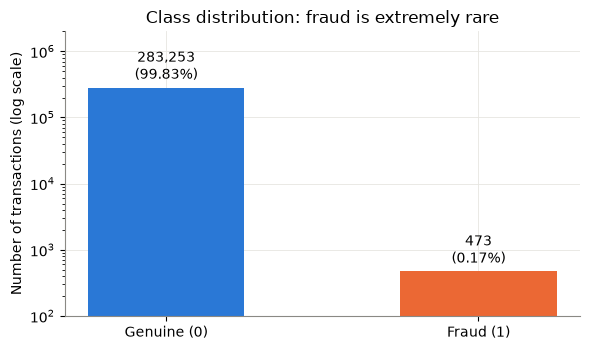

```python
counts = cc["Class"].value_counts().sort_index()
pct = cc["Class"].value_counts(normalize=True).sort_index() * 100
class_table = pd.DataFrame({"Transactions": counts, "Percent (%)": pct})
class_table.index = ["Genuine (0)", "Fraud (1)"]
print(class_table)
print(f"\nImbalance ratio: about 1 fraud for every {counts[0] // counts[1]} genuine transactions")

fig, ax = plt.subplots(figsize=(6, 3.6))
bars = ax.bar(class_table.index, class_table["Transactions"], color=[BLUE, ORANGE], width=0.5)
ax.set_yscale("log")
ax.set_ylabel("Number of transactions (log scale)")
ax.set_title("Class distribution: fraud is extremely rare")
for b, n, p in zip(bars, class_table["Transactions"], class_table["Percent (%)"]):
    ax.text(b.get_x() + b.get_width() / 2, n * 1.15, f"{n:,}\n({p:.2f}%)", ha="center", va="bottom")
ax.set_ylim(100, 2e6)
plt.tight_layout()
plt.show()
```

### Transaction amount and time by class

```
Transaction amount by class:
          mean  median         max
Class
0      88.4136 22.0000 25,691.1600
1     123.8719  9.8200  2,125.8700
```

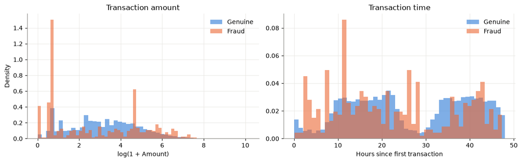

```python
print("Transaction amount by class:")
print(cc.groupby("Class")["Amount"].describe()[["mean", "50%", "max"]].rename(columns={"50%": "median"}))

fig, axes = plt.subplots(1, 2, figsize=(12, 3.8))

# Amount (log scale because it is heavily right-skewed)
for cls, col, lab in [(0, BLUE, "Genuine"), (1, ORANGE, "Fraud")]:
    axes[0].hist(np.log1p(cc.loc[cc.Class == cls, "Amount"]), bins=50, density=True,
                 alpha=0.6, color=col, label=lab)
axes[0].set_xlabel("log(1 + Amount)")
axes[0].set_ylabel("Density")
axes[0].set_title("Transaction amount")
axes[0].legend(frameon=False)

# Time converted to hours
for cls, col, lab in [(0, BLUE, "Genuine"), (1, ORANGE, "Fraud")]:
    axes[1].hist(cc.loc[cc.Class == cls, "Time"] / 3600, bins=48, density=True,
                 alpha=0.6, color=col, label=lab)
axes[1].set_xlabel("Hours since first transaction")
axes[1].set_title("Transaction time")
axes[1].legend(frameon=False)
plt.tight_layout()
plt.show()
```

### Which features are most related to fraud?

```
Strongest negative correlations:
 V17   -0.3130
V14   -0.2930
V12   -0.2510
V10   -0.2070
V16   -0.1870

Strongest positive correlations:
 V8    0.0330
V19   0.0340
V2    0.0850
V4    0.1290
V11   0.1490
```

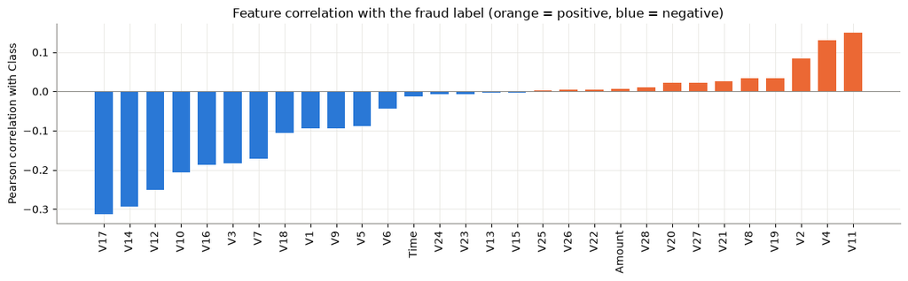

```python
corr_with_class = cc.corr()["Class"].drop("Class").sort_values()
print("Strongest negative correlations:\n", corr_with_class.head(5).round(3).to_string())
print("\nStrongest positive correlations:\n", corr_with_class.tail(5).round(3).to_string())

fig, ax = plt.subplots(figsize=(12, 3.8))
colors = [ORANGE if v > 0 else BLUE for v in corr_with_class.values]
ax.bar(corr_with_class.index, corr_with_class.values, color=colors, width=0.7)
ax.axhline(0, color=GRAY, linewidth=0.8)
ax.set_ylabel("Pearson correlation with Class")
ax.set_title("Feature correlation with the fraud label (orange = positive, blue = negative)")
plt.xticks(rotation=90)
plt.tight_layout()
plt.show()
```

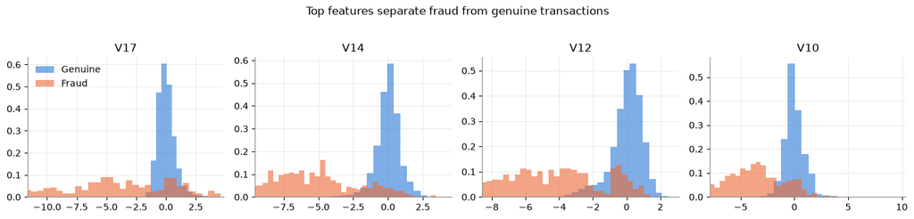

```python
# Distribution of the four most discriminating PCA features for each class
top_feats = corr_with_class.abs().sort_values(ascending=False).index[:4]
fig, axes = plt.subplots(1, 4, figsize=(14, 3.2))
for ax, f in zip(axes, top_feats):
    for cls, col, lab in [(0, BLUE, "Genuine"), (1, ORANGE, "Fraud")]:
        ax.hist(cc.loc[cc.Class == cls, f], bins=60, density=True, alpha=0.6, color=col, label=lab)
    ax.set_title(f)
    ax.set_xlim(cc[f].quantile(0.0005), cc[f].quantile(0.9995))
axes[0].legend(frameon=False)
plt.suptitle("Top features separate fraud from genuine transactions", y=1.03)
plt.tight_layout()
plt.show()
```

## A.4 Train / test split (70 / 30) and feature scaling

- `stratify=y` keeps the same (tiny) fraud percentage in both train and test sets; without it the test set could end up with too few frauds to evaluate reliably.
- `V1`–`V28` are already PCA outputs, but `Time` and `Amount` are on very different scales. Logistic regression is fitted with gradient-based optimisation and L2 regularisation, both of which work best when features are on comparable scales, so all features are standardised.
- The scaler is **fitted on the training set only** and then applied to the test set, so no information from the test data leaks into training.

```python
X = cc.drop(columns="Class")
y = cc["Class"]

X_train, X_test, y_train, y_test = train_test_split(
    X, y, test_size=0.3, stratify=y, random_state=RANDOM_STATE)

scaler = StandardScaler()
X_train_s = scaler.fit_transform(X_train)
X_test_s = scaler.transform(X_test)

print(f"Training set: {X_train.shape[0]:,} rows  |  frauds: {y_train.sum():,} ({y_train.mean()*100:.3f}%)")
print(f"Test set:     {X_test.shape[0]:,} rows  |  frauds: {y_test.sum():,} ({y_test.mean()*100:.3f}%)")
```

```
Training set: 198,608 rows  |  frauds: 331 (0.167%)
Test set:     85,118 rows  |  frauds: 142 (0.167%)
```

## A.5 Build the logistic regression model

```python
log_reg = LogisticRegression(max_iter=1000, random_state=RANDOM_STATE)
log_reg.fit(X_train_s, y_train)

y_train_pred = log_reg.predict(X_train_s)
y_test_pred = log_reg.predict(X_test_s)
y_test_proba = log_reg.predict_proba(X_test_s)[:, 1]

train_acc = accuracy_score(y_train, y_train_pred)
test_acc = accuracy_score(y_test, y_test_pred)
print(f"Training accuracy: {train_acc*100:.3f}%")
print(f"Test accuracy:     {test_acc*100:.3f}%")
```

```
Training accuracy: 99.922%
Test accuracy:     99.908%
```

## A.6 Evaluate the model

### Is accuracy enough? Compare against a "do-nothing" baseline

A model that **always predicts "genuine"** never catches a single fraud, yet it scores very high accuracy because 99.8% of transactions are genuine. Any fraud model must therefore be judged with metrics that focus on the fraud class as well.

```python
baseline_acc = (y_test == 0).mean()
print(f"Baseline accuracy (always predict 'genuine'): {baseline_acc*100:.3f}%")
print(f"Logistic regression accuracy:                 {test_acc*100:.3f}%")
print(f"Improvement over baseline: {(test_acc - baseline_acc)*100:.3f} percentage points")
```

```
Baseline accuracy (always predict 'genuine'): 99.833%
Logistic regression accuracy:                 99.908%
Improvement over baseline: 0.075 percentage points
```

```python
cm = confusion_matrix(y_test, y_test_pred)
tn, fp, fn, tp = cm.ravel()
print("Confusion matrix (rows = actual, columns = predicted):")
print(pd.DataFrame(cm, index=["Actual genuine", "Actual fraud"],
                   columns=["Predicted genuine", "Predicted fraud"]))
print(f"\nFrauds caught (TP): {tp}   Frauds missed (FN): {fn}   False alarms (FP): {fp}")

print("\nClassification report:")
print(classification_report(y_test, y_test_pred, target_names=["Genuine", "Fraud"], digits=4))

print(f"ROC-AUC:                     {roc_auc_score(y_test, y_test_proba):.4f}")
print(f"Average precision (PR-AUC):  {average_precision_score(y_test, y_test_proba):.4f}")
```

```
Confusion matrix (rows = actual, columns = predicted):
                Predicted genuine  Predicted fraud
Actual genuine              84961               15
Actual fraud                   63               79

Frauds caught (TP): 79   Frauds missed (FN): 63   False alarms (FP): 15

Classification report:
              precision    recall  f1-score   support

     Genuine     0.9993    0.9998    0.9995     84976
       Fraud     0.8404    0.5563    0.6695       142

    accuracy                         0.9991     85118
   macro avg     0.9198    0.7781    0.8345     85118
weighted avg     0.9990    0.9991    0.9990     85118

ROC-AUC:                     0.9647
Average precision (PR-AUC):  0.7040
```

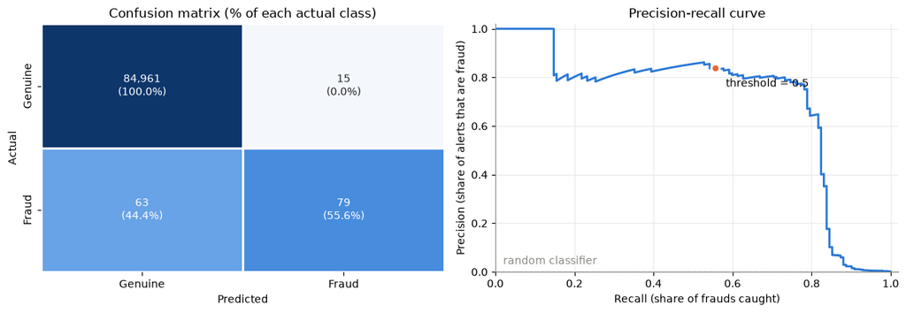

```python
fig, axes = plt.subplots(1, 2, figsize=(12, 4.2))

# Confusion matrix as percentages of each actual class (row-normalised) with counts
cm_pct = cm / cm.sum(axis=1, keepdims=True)
labels = np.array([[f"{c:,}\n({p*100:.1f}%)" for c, p in zip(rc, rp)] for rc, rp in zip(cm, cm_pct)])
sns.heatmap(cm_pct, annot=labels, fmt="", cmap=SEQ_BLUE, cbar=False, ax=axes[0],
            xticklabels=["Genuine", "Fraud"], yticklabels=["Genuine", "Fraud"], linewidths=2, linecolor="white")
axes[0].set_xlabel("Predicted")
axes[0].set_ylabel("Actual")
axes[0].set_title("Confusion matrix (% of each actual class)")

# Precision-recall curve
prec, rec, _ = precision_recall_curve(y_test, y_test_proba)
axes[1].plot(rec, prec, color=BLUE, linewidth=2)
axes[1].axhline(y_test.mean(), color=GRAY, linestyle="--", linewidth=1)
axes[1].text(0.02, y_test.mean() + 0.03, "random classifier", color=GRAY)
axes[1].scatter([recall_score(y_test, y_test_pred)], [precision_score(y_test, y_test_pred)],
                s=60, color=ORANGE, zorder=3, edgecolor="white", linewidth=2)
axes[1].annotate("threshold = 0.5", (recall_score(y_test, y_test_pred), precision_score(y_test, y_test_pred)),
                 xytext=(10, -18), textcoords="offset points")
axes[1].set_xlabel("Recall (share of frauds caught)")
axes[1].set_ylabel("Precision (share of alerts that are fraud)")
axes[1].set_title("Precision-recall curve")
axes[1].set_xlim(0, 1.02)
axes[1].set_ylim(0, 1.02)
plt.tight_layout()
plt.show()
```

### Which features drive the prediction?

Because every feature was standardised, the size of each coefficient shows how strongly that feature pushes the log-odds of fraud up (positive) or down (negative).

```
Top 10 coefficients (standardised features):
V4     0.8120
V14   -0.6360
V10   -0.6310
V22    0.3660
V9    -0.3270
V16   -0.2540
V8    -0.2440
V15   -0.2290
V21    0.2120
V20   -0.1930
```

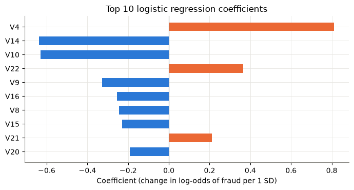

```python
coefs = pd.Series(log_reg.coef_[0], index=X.columns).sort_values(key=np.abs, ascending=False)
print("Top 10 coefficients (standardised features):")
print(coefs.head(10).round(3).to_string())

top = coefs.head(10)[::-1]
fig, ax = plt.subplots(figsize=(7, 3.8))
ax.barh(top.index, top.values, color=[ORANGE if v > 0 else BLUE for v in top.values], height=0.6)
ax.axvline(0, color=GRAY, linewidth=0.8)
ax.set_xlabel("Coefficient (change in log-odds of fraud per 1 SD)")
ax.set_title("Top 10 logistic regression coefficients")
plt.tight_layout()
plt.show()
```

### Additional experiment — handling class imbalance with `class_weight="balanced"`

The default model treats every mistake equally, so with so few frauds it leans towards predicting "genuine". Setting `class_weight="balanced"` makes each fraud example count roughly 600× more (the inverse of its frequency) in the loss. This shows the trade-off between catching frauds (recall) and raising false alarms (precision).

```python
log_reg_bal = LogisticRegression(max_iter=1000, class_weight="balanced", random_state=RANDOM_STATE)
log_reg_bal.fit(X_train_s, y_train)
y_pred_bal = log_reg_bal.predict(X_test_s)
proba_bal = log_reg_bal.predict_proba(X_test_s)[:, 1]

def summarise(name, y_true, y_pred, y_proba):
    tn, fp, fn, tp = confusion_matrix(y_true, y_pred).ravel()
    return {"Model": name, "Accuracy": accuracy_score(y_true, y_pred),
            "Precision (fraud)": precision_score(y_true, y_pred), "Recall (fraud)": recall_score(y_true, y_pred),
            "F1 (fraud)": f1_score(y_true, y_pred), "ROC-AUC": roc_auc_score(y_true, y_proba),
            "Frauds caught": tp, "Frauds missed": fn, "False alarms": fp}

comparison_a = pd.DataFrame([
    summarise("Logistic regression (default)", y_test, y_test_pred, y_test_proba),
    summarise("Logistic regression (balanced weights)", y_test, y_pred_bal, proba_bal),
]).set_index("Model")
comparison_a
```

| Model | Accuracy | Precision (fraud) | Recall (fraud) | F1 (fraud) | ROC-AUC | Frauds caught | Frauds missed | False alarms |
| --- | --- | --- | --- | --- | --- | --- | --- | --- |
| Logistic regression (default) | 0.9991 | 0.8404 | 0.5563 | 0.6695 | 0.9647 | 79 | 63 | 15 |
| Logistic regression (balanced weights) | 0.9732 | 0.0527 | 0.8873 | 0.0994 | 0.9663 | 126 | 16 | 2267 |

## A.7 Part A — Findings

**Data and preprocessing**

- The dataset has **284,807 transactions and 31 columns** with **no missing values**. **1,081 duplicate rows** were removed, leaving 283,726.
- The classes are **extremely imbalanced**: only **473 frauds (0.167%)**, about 1 fraud for every 598 genuine transactions. A stratified 70/30 split kept that ratio in both sets (331 frauds in training, 142 in test).
- Fraudulent transactions have a lower median amount ($9.82 vs $22.00) but a higher mean, so fraud includes many small "test" charges plus some larger ones.
- The PCA features **V17, V14, V12 and V10** have the strongest (negative) correlation with fraud, and **V11 and V4** the strongest positive correlation. Their distributions clearly separate the two classes, which is why a linear model can work well here.

**Model performance (test set, 85,118 transactions)**

- **Accuracy = 99.91%** (training 99.92%, so there is no sign of overfitting).
- That figure has to be read in context: a model that always says "genuine" already scores **99.83%**. The real gain is only 0.075 percentage points, so **accuracy on its own is a misleading metric for imbalanced data**.
- The fraud-focused metrics give a truer picture:
  - **Precision 0.84**: when the model raises an alert, it is right 84% of the time (only 15 false alarms).
  - **Recall 0.56**: it catches **79 of 142 frauds** but **misses 63**.
  - **F1 = 0.67, ROC-AUC = 0.965, PR-AUC = 0.70**. The model ranks transactions by risk very well, but the default 0.5 threshold is cautious about flagging fraud.
- The most influential features are **V4** (raises fraud risk) and **V14 and V10** (lower values point strongly to fraud), consistent with the correlation analysis.

**Imbalance experiment**

- With `class_weight="balanced"`, **recall jumps from 56% to 89%** (126 of 142 frauds caught), but false alarms rise from 15 to **2,267** and accuracy drops to 97.3%. ROC-AUC barely changes (0.965 → 0.966), which shows the ranking ability is the same; only the trade-off point moves.
- Which model is "better" depends on the business cost of a missed fraud versus a blocked genuine customer. In practice, tuning the decision threshold, resampling (e.g. SMOTE) or non-linear models (e.g. gradient boosting) would be the next steps.

# Part B — Insurance Cost Prediction with Linear Regression

**Problem statement:** Using the Kaggle *Medical Cost Personal* (insurance) dataset, build a predictive system to predict insurance costs. Demonstrate data preprocessing and analysis, split the data into train (0.7) and test (0.3), build the model with **linear regression**, and evaluate how accurately it predicts insurance cost.

**About the data:**

- `age` – age of the primary beneficiary
- `sex` – female / male
- `bmi` – body mass index (kg/m²); 18.5–24.9 is the healthy range
- `children` – number of dependants covered by the plan
- `smoker` – yes / no
- `region` – US residential area: northeast, southeast, southwest, northwest
- `charges` – **target**: individual medical costs billed by the insurer (USD)

## B.1 Load and inspect the data

```python
import os
ins = pd.read_csv("insurance.csv")
print("Loaded:", "insurance.csv")
print("Shape (rows, columns):", ins.shape)
ins.head()
```

```
Loaded: insurance.csv
Shape (rows, columns): (1338, 7)
```

|  | age | sex | bmi | children | smoker | region | charges |
| --- | --- | --- | --- | --- | --- | --- | --- |
| 0 | 19 | female | 27.9000 | 0 | yes | southwest | 16,884.9240 |
| 1 | 18 | male | 33.7700 | 1 | no | southeast | 1,725.5523 |
| 2 | 28 | male | 33.0000 | 3 | no | southeast | 4,449.4620 |
| 3 | 33 | male | 22.7050 | 0 | no | northwest | 21,984.4706 |
| 4 | 32 | male | 28.8800 | 0 | no | northwest | 3,866.8552 |

```python
ins.info()
```

```
<class 'pandas.DataFrame'>
RangeIndex: 1338 entries, 0 to 1337
Data columns (total 7 columns):
 #   Column    Non-Null Count  Dtype
---  ------    --------------  -----
 0   age       1338 non-null   int64
 1   sex       1338 non-null   str
 2   bmi       1338 non-null   float64
 3   children  1338 non-null   int64
 4   smoker    1338 non-null   str
 5   region    1338 non-null   str
 6   charges   1338 non-null   float64
dtypes: float64(2), int64(2), str(3)
memory usage: 73.3 KB
```

```python
ins.describe().T
```

|  | count | mean | std | min | 25% | 50% | 75% | max |
| --- | --- | --- | --- | --- | --- | --- | --- | --- |
| age | 1,338.0000 | 39.2070 | 14.0500 | 18.0000 | 27.0000 | 39.0000 | 51.0000 | 64.0000 |
| bmi | 1,338.0000 | 30.6634 | 6.0982 | 15.9600 | 26.2963 | 30.4000 | 34.6938 | 53.1300 |
| children | 1,338.0000 | 1.0949 | 1.2055 | 0.0000 | 0.0000 | 1.0000 | 2.0000 | 5.0000 |
| charges | 1,338.0000 | 13,270.4223 | 12,110.0112 | 1,121.8739 | 4,740.2872 | 9,382.0330 | 16,639.9125 | 63,770.4280 |

```python
for col in ["sex", "smoker", "region"]:
    print(ins[col].value_counts().to_string(), "\n")
```

```
sex
male      676
female    662

smoker
no     1064
yes     274

region
southeast    364
southwest    325
northwest    325
northeast    324
```

## B.2 Data preprocessing — missing values and duplicates

```python
print("Missing values per column:")
print(ins.isnull().sum().to_string())
print("\nDuplicate rows:", ins.duplicated().sum())
display(ins[ins.duplicated(keep=False)])

ins = ins.drop_duplicates().reset_index(drop=True)
print("Shape after removing duplicates:", ins.shape)
```

```
Missing values per column:
age         0
sex         0
bmi         0
children    0
smoker      0
region      0
charges     0

Duplicate rows: 1
```

|  | age | sex | bmi | children | smoker | region | charges |
| --- | --- | --- | --- | --- | --- | --- | --- |
| 195 | 19 | male | 30.5900 | 0 | no | northwest | 1,639.5631 |
| 581 | 19 | male | 30.5900 | 0 | no | northwest | 1,639.5631 |

```
Shape after removing duplicates: (1337, 7)
```

> Only one duplicate was found, so removing it has a negligible effect on results; it is dropped for consistency with Part A and because an exact match on every column is most likely a data-entry error.

## B.3 Exploratory data analysis

```
Skewness of charges: 1.52  (mean $13,279 vs median $9,386)
```

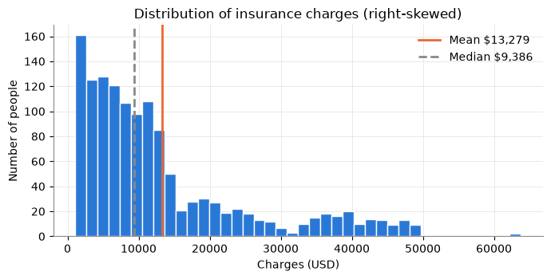

```python
print(f"Skewness of charges: {ins['charges'].skew():.2f}  (mean ${ins['charges'].mean():,.0f} vs median ${ins['charges'].median():,.0f})")

fig, ax = plt.subplots(figsize=(7, 3.6))
ax.hist(ins["charges"], bins=40, color=BLUE, edgecolor="white", linewidth=1)
ax.axvline(ins["charges"].mean(), color=ORANGE, linewidth=2, label=f"Mean ${ins['charges'].mean():,.0f}")
ax.axvline(ins["charges"].median(), color=GRAY, linewidth=2, linestyle="--", label=f"Median ${ins['charges'].median():,.0f}")
ax.set_xlabel("Charges (USD)")
ax.set_ylabel("Number of people")
ax.set_title("Distribution of insurance charges (right-skewed)")
ax.legend(frameon=False)
plt.tight_layout()
plt.show()
```

```python
summary = pd.concat({
    "smoker": ins.groupby("smoker")["charges"].agg(["count", "mean", "median"]),
    "sex": ins.groupby("sex")["charges"].agg(["count", "mean", "median"]),
    "region": ins.groupby("region")["charges"].agg(["count", "mean", "median"]),
    "children": ins.groupby("children")["charges"].agg(["count", "mean", "median"]),
})
summary["count"] = summary["count"].astype(int)
print("Average charges (USD) by group:")
summary.style.format({"count": "{:,}", "mean": "${:,.0f}", "median": "${:,.0f}"})
```

```
Average charges (USD) by group:
```

|  |  | count | mean | median |
| --- | --- | --- | --- | --- |
| smoker | no | 1,063 | $8,441 | $7,346 |
|  | yes | 274 | $32,050 | $34,456 |
| sex | female | 662 | $12,570 | $9,413 |
|  | male | 675 | $13,975 | $9,378 |
| region | northeast | 324 | $13,406 | $10,058 |
|  | northwest | 324 | $12,451 | $8,977 |
|  | southeast | 364 | $14,735 | $9,294 |
|  | southwest | 325 | $12,347 | $8,799 |
| children | 0 | 573 | $12,385 | $9,863 |
|  | 1 | 324 | $12,731 | $8,484 |
|  | 2 | 240 | $15,074 | $9,265 |
|  | 3 | 157 | $15,355 | $10,601 |
|  | 4 | 25 | $13,851 | $11,034 |
|  | 5 | 18 | $8,786 | $8,590 |

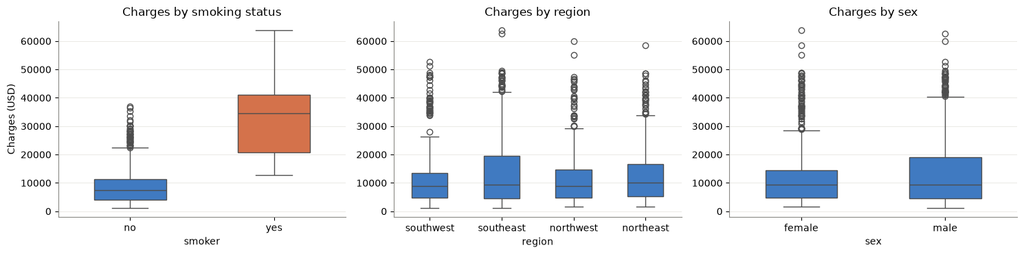

```python
fig, axes = plt.subplots(1, 3, figsize=(15, 3.8))
order = ["no", "yes"]
sns.boxplot(data=ins, x="smoker", y="charges", order=order, palette=[BLUE, ORANGE], ax=axes[0],
            hue="smoker", hue_order=order, legend=False, width=0.5)
axes[0].set_title("Charges by smoking status")
axes[0].set_ylabel("Charges (USD)")

sns.boxplot(data=ins, x="region", y="charges", color=BLUE, ax=axes[1], width=0.5)
axes[1].set_title("Charges by region")
axes[1].set_ylabel("")

sns.boxplot(data=ins, x="sex", y="charges", color=BLUE, ax=axes[2], width=0.5)
axes[2].set_title("Charges by sex")
axes[2].set_ylabel("")
plt.tight_layout()
plt.show()
```

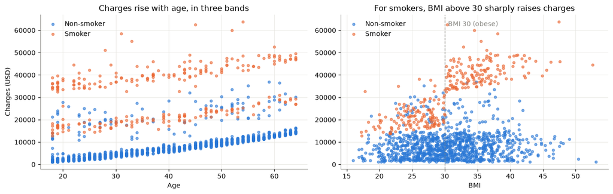

```python
fig, axes = plt.subplots(1, 2, figsize=(13, 4.2))
for s, col, lab in [("no", BLUE, "Non-smoker"), ("yes", ORANGE, "Smoker")]:
    d = ins[ins.smoker == s]
    axes[0].scatter(d["age"], d["charges"], s=14, alpha=0.6, color=col, label=lab)
    axes[1].scatter(d["bmi"], d["charges"], s=14, alpha=0.6, color=col, label=lab)
axes[0].set_xlabel("Age")
axes[0].set_ylabel("Charges (USD)")
axes[0].set_title("Charges rise with age, in three bands")
axes[1].axvline(30, color=GRAY, linestyle="--", linewidth=1)
axes[1].text(30.5, ins.charges.max() * 0.97, "BMI 30 (obese)", color=GRAY)
axes[1].set_xlabel("BMI")
axes[1].set_title("For smokers, BMI above 30 sharply raises charges")
for ax in axes:
    ax.legend(frameon=False)
plt.tight_layout()
plt.show()
```

## B.4 Encode categorical variables

Linear regression needs numeric inputs.

- `sex` and `smoker` have two values each, so they become 0/1 columns (`male`, `smoker`).
- `region` has four unordered values, so it is **one-hot encoded**. One column (northeast) is dropped and acts as the reference category; keeping all four would make them perfectly collinear with the intercept (the "dummy variable trap").

```python
ins_enc = ins.copy()
ins_enc["sex"] = (ins_enc["sex"] == "male").astype(int)
ins_enc["smoker"] = (ins_enc["smoker"] == "yes").astype(int)
ins_enc = pd.get_dummies(ins_enc, columns=["region"], drop_first=True, dtype=int)
ins_enc = ins_enc.rename(columns={"sex": "male"})
ins_enc.head()
```

|  | age | male | bmi | children | smoker | charges | region_northwest | region_southeast | region_southwest |
| --- | --- | --- | --- | --- | --- | --- | --- | --- | --- |
| 0 | 19 | 0 | 27.9000 | 0 | 1 | 16,884.9240 | 0 | 0 | 1 |
| 1 | 18 | 1 | 33.7700 | 1 | 0 | 1,725.5523 | 0 | 1 | 0 |
| 2 | 28 | 1 | 33.0000 | 3 | 0 | 4,449.4620 | 0 | 1 | 0 |
| 3 | 33 | 1 | 22.7050 | 0 | 0 | 21,984.4706 | 1 | 0 | 0 |
| 4 | 32 | 1 | 28.8800 | 0 | 0 | 3,866.8552 | 1 | 0 | 0 |

```
Correlation with charges:
smoker              0.7870
age                 0.2980
bmi                 0.1980
region_southeast    0.0740
children            0.0670
male                0.0580
region_northwest   -0.0390
region_southwest   -0.0440
```

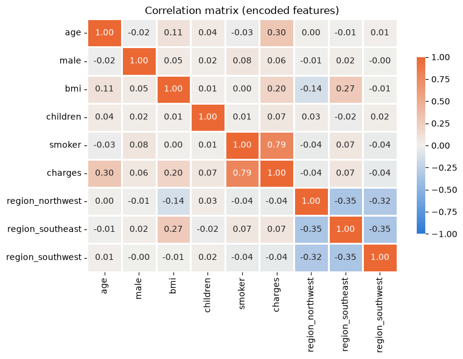

```python
corr = ins_enc.corr()
print("Correlation with charges:")
print(corr["charges"].drop("charges").sort_values(ascending=False).round(3).to_string())

fig, ax = plt.subplots(figsize=(8, 6))
sns.heatmap(corr, annot=True, fmt=".2f", cmap=DIVERGING, vmin=-1, vmax=1, ax=ax,
            linewidths=2, linecolor="white", cbar_kws={"shrink": 0.7})
ax.set_title("Correlation matrix (encoded features)")
plt.tight_layout()
plt.show()
```

## B.5 Train / test split (70 / 30)

Ordinary least squares linear regression is not affected by feature scale (the coefficients simply adjust), so the features are left in their original units. That keeps the coefficients directly readable as *dollars per unit*.

```python
X_ins = ins_enc.drop(columns="charges")
y_ins = ins_enc["charges"]

Xi_train, Xi_test, yi_train, yi_test = train_test_split(
    X_ins, y_ins, test_size=0.3, random_state=RANDOM_STATE)

print(f"Training set: {Xi_train.shape[0]} rows  |  Test set: {Xi_test.shape[0]} rows")
print("Features:", list(X_ins.columns))
```

```
Training set: 935 rows  |  Test set: 402 rows
Features: ['age', 'male', 'bmi', 'children', 'smoker', 'region_northwest', 'region_southeast', 'region_southwest']
```

## B.6 Build the linear regression model

```python
lin_reg = LinearRegression()
lin_reg.fit(Xi_train, yi_train)

coef_table = pd.DataFrame({"Coefficient (USD)": lin_reg.coef_}, index=X_ins.columns)
print(f"Intercept: ${lin_reg.intercept_:,.2f}")
coef_table.sort_values("Coefficient (USD)", ascending=False).round(2)
```

```
Intercept: $-11,516.78
```

|  | Coefficient (USD) |
| --- | --- |
| smoker | 22,874.4500 |
| children | 522.1600 |
| bmi | 328.3800 |
| age | 251.2500 |
| male | -111.9100 |
| region_northwest | -465.7500 |
| region_southwest | -765.5800 |
| region_southeast | -936.1000 |

**Reading the coefficients:** holding everything else constant, each coefficient is the change in predicted annual charges for a one-unit increase in that feature, e.g. the `smoker` coefficient is the extra cost of being a smoker compared with a non-smoker with the same age, BMI, etc.

## B.7 Evaluate the model

For a regression model "accuracy" is measured by how close predictions are to the true values:

- **R²** – share of the variation in charges that the model explains (1.0 = perfect)
- **MAE** – average absolute error in dollars
- **RMSE** – root mean squared error in dollars (penalises large misses more)

```python
yi_train_pred = lin_reg.predict(Xi_train)
yi_test_pred = lin_reg.predict(Xi_test)

def reg_metrics(y_true, y_pred):
    return {"R²": r2_score(y_true, y_pred),
            "MAE (USD)": mean_absolute_error(y_true, y_pred),
            "RMSE (USD)": np.sqrt(mean_squared_error(y_true, y_pred))}

metrics_b = pd.DataFrame({"Train": reg_metrics(yi_train, yi_train_pred),
                          "Test": reg_metrics(yi_test, yi_test_pred)}).T
print(f"The model explains {metrics_b.loc['Test', 'R²']*100:.1f}% of the variance in insurance charges on unseen test data.")

cv_r2 = cross_val_score(LinearRegression(), Xi_train, yi_train, cv=5, scoring="r2")
print(f"5-fold cross-validated R² on the training set: {cv_r2.mean():.4f} ± {cv_r2.std():.4f}")
metrics_b
```

```
The model explains 77.2% of the variance in insurance charges on unseen test data.
5-fold cross-validated R² on the training set: 0.7293 ± 0.0309
```

|  | R² | MAE (USD) | RMSE (USD) |
| --- | --- | --- | --- |
| Train | 0.7363 | 4,165.8309 | 5,984.3908 |
| Test | 0.7724 | 4,181.8160 | 6,240.2059 |

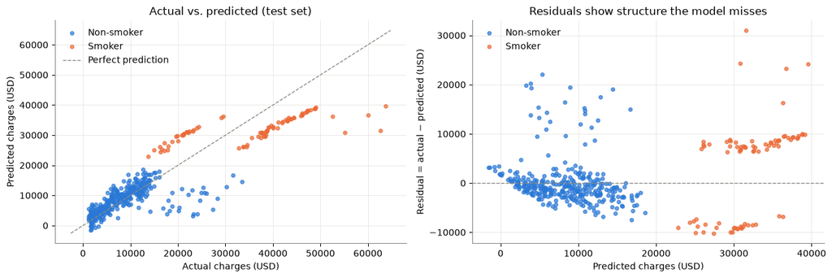

```python
fig, axes = plt.subplots(1, 2, figsize=(13, 4.4))
is_smoker = Xi_test["smoker"] == 1
for mask, col, lab in [(~is_smoker, BLUE, "Non-smoker"), (is_smoker, ORANGE, "Smoker")]:
    axes[0].scatter(yi_test[mask], yi_test_pred[mask], s=16, alpha=0.7, color=col, label=lab)
lims = [min(yi_test.min(), yi_test_pred.min()) - 1000, yi_test.max() + 1000]
axes[0].plot(lims, lims, color=GRAY, linestyle="--", linewidth=1, label="Perfect prediction")
axes[0].set_xlabel("Actual charges (USD)")
axes[0].set_ylabel("Predicted charges (USD)")
axes[0].set_title("Actual vs. predicted (test set)")
axes[0].legend(frameon=False)

residuals = yi_test - yi_test_pred
for mask, col, lab in [(~is_smoker, BLUE, "Non-smoker"), (is_smoker, ORANGE, "Smoker")]:
    axes[1].scatter(yi_test_pred[mask], residuals[mask], s=16, alpha=0.7, color=col, label=lab)
axes[1].axhline(0, color=GRAY, linestyle="--", linewidth=1)
axes[1].set_xlabel("Predicted charges (USD)")
axes[1].set_ylabel("Residual = actual − predicted (USD)")
axes[1].set_title("Residuals show structure the model misses")
axes[1].legend(frameon=False)
plt.tight_layout()
plt.show()
```

## B.8 The predictive system

A small function wraps the trained model so it can predict the cost for a new person from raw, human-readable inputs.

```python
def predict_insurance_cost(age, sex, bmi, children, smoker, region, model=lin_reg, columns=X_ins.columns):
    # Predict annual insurance charges (USD) for one person.
    row = {"age": age, "male": int(sex == "male"), "bmi": bmi, "children": children,
           "smoker": int(smoker == "yes"),
           "region_northwest": int(region == "northwest"),
           "region_southeast": int(region == "southeast"),
           "region_southwest": int(region == "southwest")}
    return float(model.predict(pd.DataFrame([row])[columns])[0])

examples = pd.DataFrame([
    dict(age=31, sex="female", bmi=25.7, children=0, smoker="no", region="southeast"),
    dict(age=31, sex="female", bmi=25.7, children=0, smoker="yes", region="southeast"),
    dict(age=52, sex="male", bmi=34.1, children=2, smoker="no", region="northwest"),
    dict(age=52, sex="male", bmi=34.1, children=2, smoker="yes", region="northwest"),
])
examples["Predicted charges (USD)"] = [predict_insurance_cost(**r) for r in examples.to_dict("records")]
examples.style.format({"Predicted charges (USD)": "${:,.2f}", "bmi": "{:.1f}"})
```

|  | age | sex | bmi | children | smoker | region | Predicted charges (USD) |
| --- | --- | --- | --- | --- | --- | --- | --- |
| 0 | 31 | female | 25.7 | 0 | no | southeast | $3,775.20 |
| 1 | 31 | female | 25.7 | 0 | yes | southeast | $26,649.64 |
| 2 | 52 | male | 34.1 | 2 | no | northwest | $13,212.54 |
| 3 | 52 | male | 34.1 | 2 | yes | northwest | $36,086.99 |

```python
# Check the system on a few real people from the test set
sample = ins.loc[Xi_test.index[:5]].copy()
sample["Predicted"] = [predict_insurance_cost(r.age, r.sex, r.bmi, r.children, r.smoker, r.region)
                       for r in sample.itertuples()]
sample["Error"] = sample["Predicted"] - sample["charges"]
sample.style.format({"charges": "${:,.2f}", "Predicted": "${:,.2f}", "Error": lambda v: f"-${abs(v):,.2f}" if v < 0 else f"${v:,.2f}", "bmi": "{:.2f}"})
```

|  | age | sex | bmi | children | smoker | region | charges | Predicted | Error |
| --- | --- | --- | --- | --- | --- | --- | --- | --- | --- |
| 899 | 49 | male | 22.52 | 0 | no | northeast | $8,688.86 | $8,075.92 | -$612.94 |
| 1063 | 29 | female | 25.60 | 4 | no | southwest | $5,708.87 | $5,499.00 | -$209.86 |
| 1255 | 51 | female | 36.38 | 3 | no | northwest | $11,436.74 | $14,345.71 | $2,908.97 |
| 298 | 31 | male | 34.39 | 3 | yes | northwest | $38,746.36 | $31,428.20 | -$7,318.15 |
| 237 | 31 | male | 38.39 | 2 | no | southeast | $4,463.21 | $8,874.78 | $4,411.58 |

### Additional experiment — improving the linear model with feature engineering

The EDA showed two patterns that a plain straight-line model cannot capture: charges for **smokers jump sharply once BMI exceeds 30**, and cost grows faster at older ages. Linear regression is still *linear in its coefficients*, so we can add engineered features and keep the same algorithm:

- `obese` = 1 if BMI ≥ 30
- `smoker_obese` = smoker × obese (interaction)
- `age_sq` = age² (curvature)

```python
def add_features(df):
    df = df.copy()
    df["obese"] = (df["bmi"] >= 30).astype(int)
    df["smoker_obese"] = df["smoker"] * df["obese"]
    df["age_sq"] = df["age"] ** 2
    return df

Xf_train, Xf_test = add_features(Xi_train), add_features(Xi_test)
lin_reg_fe = LinearRegression().fit(Xf_train, yi_train)
yf_test_pred = lin_reg_fe.predict(Xf_test)

comparison_b = pd.DataFrame({
    "Baseline linear regression": reg_metrics(yi_test, yi_test_pred),
    "With engineered features": reg_metrics(yi_test, yf_test_pred),
}).T
print("Test-set comparison:")
comparison_b
```

```
Test-set comparison:
```

|  | R² | MAE (USD) | RMSE (USD) |
| --- | --- | --- | --- |
| Baseline linear regression | 0.7724 | 4,181.8160 | 6,240.2059 |
| With engineered features | 0.8750 | 2,515.2677 | 4,624.0056 |

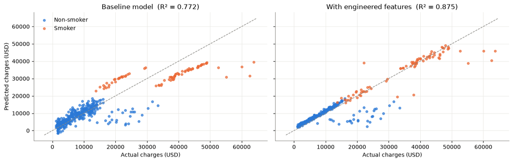

```python
fig, axes = plt.subplots(1, 2, figsize=(13, 4.2), sharey=True)
for ax, pred, title in [(axes[0], yi_test_pred, "Baseline model"), (axes[1], yf_test_pred, "With engineered features")]:
    for mask, col, lab in [(~is_smoker, BLUE, "Non-smoker"), (is_smoker, ORANGE, "Smoker")]:
        ax.scatter(yi_test[mask], pred[mask], s=16, alpha=0.7, color=col, label=lab)
    ax.plot(lims, lims, color=GRAY, linestyle="--", linewidth=1)
    ax.set_title(f"{title}  (R² = {r2_score(yi_test, pred):.3f})")
    ax.set_xlabel("Actual charges (USD)")
axes[0].set_ylabel("Predicted charges (USD)")
axes[0].legend(frameon=False)
plt.tight_layout()
plt.show()
```

## B.9 Part B — Findings

**Data and preprocessing**

- The dataset has **1,338 records and 7 columns** with **no missing values**. **One duplicate row** was removed (1,337 remain).
- `sex` and `smoker` were binary-encoded and `region` was one-hot encoded (northeast as reference). The data was split 70/30 (935 train, 402 test).
- `charges` is **right-skewed** (mean $13,279 vs median $9,386): most people have modest costs and a minority have very high costs.

**What drives insurance cost (EDA)**

- **Smoking is by far the strongest factor** (correlation 0.79). Smokers average **$32,050** against **$8,441** for non-smokers, almost 4× higher.
- **Age** is the second driver (correlation 0.30): charges rise steadily with age in three bands (non-smokers, a mixed middle band, and smokers).
- **BMI** matters mostly through its **interaction with smoking**: smokers with BMI ≥ 30 form a distinct high-cost group (around $40k and above).
- Sex, region and number of children have only small effects.

**Linear regression model**

- Fitted coefficients: being a **smoker adds about $22,874**, each extra **year of age adds about $251**, each **BMI point adds about $328**, and each **child adds about $522**. Sex and region shift costs by less than $1,000.
- **Test R² = 0.772**: the model explains **77.2% of the variation** in insurance charges on unseen data. **MAE ≈ $4,182** and **RMSE ≈ $6,240**.
- Training R² (0.736) and 5-fold cross-validated R² (0.729 ± 0.031) are close to the test score, so the model **generalises well and is not overfitting**.
- The residual plot shows clear structure: the model under-predicts obese smokers and over-predicts some non-obese smokers, because a single straight line cannot represent the smoker × BMI jump.

**Improving the model**

- Adding three engineered features (`obese`, `smoker × obese`, `age²`) while keeping linear regression raised **test R² from 0.772 to 0.875** and cut **MAE from $4,182 to $2,515** (about 40% lower). Good feature engineering based on EDA can matter more than switching algorithms.
- The `predict_insurance_cost()` function turns the trained model into a usable predictive system: for example, a 31-year-old non-smoking woman versus an otherwise identical smoker differ by about $22,900 in predicted cost.

# Overall conclusion

|  | Part A — Logistic Regression | Part B — Linear Regression |
| --- | --- | --- |
| Task | Classify a transaction as fraud / genuine | Predict a continuous cost in USD |
| Headline result | **Accuracy 99.91%** (ROC-AUC 0.965) | **R² 0.772** (0.875 with engineered features) |
| Key lesson | Accuracy is misleading with imbalanced classes; precision, recall and the confusion matrix tell the real story | Linear models are easy to interpret; EDA-driven features capture non-linear effects |

Both algorithms learn a weighted sum of the inputs. Linear regression uses it directly as the prediction, while logistic regression passes it through a sigmoid to produce a probability. Both are fast, interpretable baselines: their coefficients show which features matter and in which direction. Their limits (a single linear decision boundary, no automatic interactions) appeared in both parts, and were addressed by rebalancing the classes in Part A and by feature engineering in Part B.